# Exploration of Prosper Loan Dataset

## by Farnaz Zarian

### Project Overview

This project explores data from Prosper which is America's first [marketplace lending platform](https://www.prosper.com/personal-loans). Prosper has funded over 12 billion dollars in loans. On porsper, borrowers list their loan requests between 2,000 and 40,000 dollars and individual investors can invest in as little as 25 dollars in their listing of choice.

### Preliminary Wrangling & Exploratory Data Analysis

This exploration will contain statistics with visualizations to build understanding of Prosper dataset. The dataset consists of 81 variables and 113,937 observations. Visualizations will include univariate, bivariate and multivariate visualizations of several variables in the dataset, allowing the reader to gain understanding of variable distributions as well as their relationships.

```python
# import all packages and set plots to be embedded inline
import numpy as np
import pandas as pd
import matplotlib.pyplot as plt
import seaborn as sb

%matplotlib inline

# suppress warnings from final output
import warnings
warnings.simplefilter("ignore")
```

> Load in your dataset and describe its properties through the questions below. Try and motivate your exploration goals through this section.

```python
loans = pd.read_csv(r'C:\\Users\zariped\Desktop\Data_Science\Udacity\data_visualization\prosperLoanData.csv')
```

```python
# high-level overview of data shape and composition
print(loans.shape)
print(loans.dtypes)
loans.head(10)
```

```
(113937, 81)
ListingKey                      object
ListingNumber                    int64
ListingCreationDate             object
CreditGrade                     object
Term                             int64
                                ...
PercentFunded                  float64
Recommendations                  int64
InvestmentFromFriendsCount       int64
InvestmentFromFriendsAmount    float64
Investors                        int64
Length: 81, dtype: object
```

|  | ListingKey | ListingNumber | ListingCreationDate | CreditGrade | Term | LoanStatus | ClosedDate | BorrowerAPR | BorrowerRate | LenderYield | ... | LP_ServiceFees | LP_CollectionFees | LP_GrossPrincipalLoss | LP_NetPrincipalLoss | LP_NonPrincipalRecoverypayments | PercentFunded | Recommendations | InvestmentFromFriendsCount | InvestmentFromFriendsAmount | Investors |
| --- | --- | --- | --- | --- | --- | --- | --- | --- | --- | --- | --- | --- | --- | --- | --- | --- | --- | --- | --- | --- | --- |
| 0 | 1021339766868145413AB3B | 193129 | 2007-08-26 19:09:29.263000000 | C | 36 | Completed | 2009-08-14 00:00:00 | 0.16516 | 0.1580 | 0.1380 | ... | -133.18 | 0.0 | 0.0 | 0.0 | 0.0 | 1.0 | 0 | 0 | 0.0 | 258 |
| 1 | 10273602499503308B223C1 | 1209647 | 2014-02-27 08:28:07.900000000 | NaN | 36 | Current | NaN | 0.12016 | 0.0920 | 0.0820 | ... | 0.00 | 0.0 | 0.0 | 0.0 | 0.0 | 1.0 | 0 | 0 | 0.0 | 1 |
| 2 | 0EE9337825851032864889A | 81716 | 2007-01-05 15:00:47.090000000 | HR | 36 | Completed | 2009-12-17 00:00:00 | 0.28269 | 0.2750 | 0.2400 | ... | -24.20 | 0.0 | 0.0 | 0.0 | 0.0 | 1.0 | 0 | 0 | 0.0 | 41 |
| 3 | 0EF5356002482715299901A | 658116 | 2012-10-22 11:02:35.010000000 | NaN | 36 | Current | NaN | 0.12528 | 0.0974 | 0.0874 | ... | -108.01 | 0.0 | 0.0 | 0.0 | 0.0 | 1.0 | 0 | 0 | 0.0 | 158 |
| 4 | 0F023589499656230C5E3E2 | 909464 | 2013-09-14 18:38:39.097000000 | NaN | 36 | Current | NaN | 0.24614 | 0.2085 | 0.1985 | ... | -60.27 | 0.0 | 0.0 | 0.0 | 0.0 | 1.0 | 0 | 0 | 0.0 | 20 |
| 5 | 0F05359734824199381F61D | 1074836 | 2013-12-14 08:26:37.093000000 | NaN | 60 | Current | NaN | 0.15425 | 0.1314 | 0.1214 | ... | -25.33 | 0.0 | 0.0 | 0.0 | 0.0 | 1.0 | 0 | 0 | 0.0 | 1 |
| 6 | 0F0A3576754255009D63151 | 750899 | 2013-04-12 09:52:56.147000000 | NaN | 36 | Current | NaN | 0.31032 | 0.2712 | 0.2612 | ... | -22.95 | 0.0 | 0.0 | 0.0 | 0.0 | 1.0 | 0 | 0 | 0.0 | 1 |
| 7 | 0F1035772717087366F9EA7 | 768193 | 2013-05-05 06:49:27.493000000 | NaN | 36 | Current | NaN | 0.23939 | 0.2019 | 0.1919 | ... | -69.21 | 0.0 | 0.0 | 0.0 | 0.0 | 1.0 | 0 | 0 | 0.0 | 1 |
| 8 | 0F043596202561788EA13D5 | 1023355 | 2013-12-02 10:43:39.117000000 | NaN | 36 | Current | NaN | 0.07620 | 0.0629 | 0.0529 | ... | -16.77 | 0.0 | 0.0 | 0.0 | 0.0 | 1.0 | 0 | 0 | 0.0 | 1 |
| 9 | 0F043596202561788EA13D5 | 1023355 | 2013-12-02 10:43:39.117000000 | NaN | 36 | Current | NaN | 0.07620 | 0.0629 | 0.0529 | ... | -16.77 | 0.0 | 0.0 | 0.0 | 0.0 | 1.0 | 0 | 0 | 0.0 | 1 |

10 rows × 81 columns

```python
# descriptive statistics for numeric variables
loans.info()
```

```
<class 'pandas.core.frame.DataFrame'>
RangeIndex: 113937 entries, 0 to 113936
Data columns (total 81 columns):
 #   Column                               Non-Null Count   Dtype
---  ------                               --------------   -----
 0   ListingKey                           113937 non-null  object
 1   ListingNumber                        113937 non-null  int64
 2   ListingCreationDate                  113937 non-null  object
 3   CreditGrade                          28953 non-null   object
 4   Term                                 113937 non-null  int64
 5   LoanStatus                           113937 non-null  object
 6   ClosedDate                           55089 non-null   object
 7   BorrowerAPR                          113912 non-null  float64
 8   BorrowerRate                         113937 non-null  float64
 9   LenderYield                          113937 non-null  float64
```

[output cut: 73 more lines]

### What is the structure of the dataset?

The loan dataset consists of 113,937 rows and 81 columns. 61 of the 81 variables are numeric, most of which have no missing values.

### What is/are the main feature(s) of interest in the dataset?

*Borrower APR* and *Original Loan Amount* are the main features of interest in this exploration.

### What features in the dataset do you think will help support your investigation into your feature(s) of interest?

*DebtToIncomeRatio*, *Stated Monthly Income*, *Cumulative service fees paid by the investors who have invested in the loan*, *Borrower State*, *Occupation*, *Loan Status*, *Loan Term* and *Employment Status* can help support my investigation into the main features of interest.

## Univariate Exploration

> In this section, I will investigate distributions of individual variables.

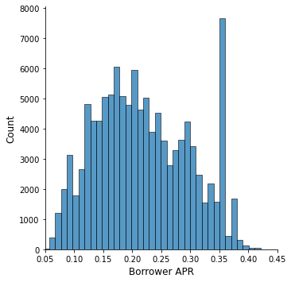

```python
# Look at the histogram of the Borrower APR
sb.displot(loans['BorrowerAPR'], kind = 'hist', bins=50);
plt.xlim(0.05, .45);
plt.xlabel('Borrower APR', fontsize=12);
plt.ylabel('Count', fontsize=12);
```

###### The distribution of borrower APR looks multimodal. There are small peaks around 0.1, 0.13, 0.2, 0.22, 0.24, 0.29, 0.3 and 0.37 APRS. There is a sharp peak around 0.36 APR. There are very few loans with APRs more than 0.42.

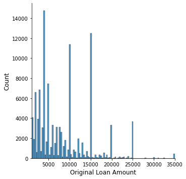

```python
# Look at the histogram of the loan original amount
bins = np.arange(0, loans['LoanOriginalAmount'].max()+ 100, 100);
sb.displot(loans['LoanOriginalAmount'], kind = 'hist', bins=100);
plt.xlim(1000, 35000);
plt.xlabel('Original Loan Amount', fontsize=12);
plt.ylabel('Count', fontsize=12);
```

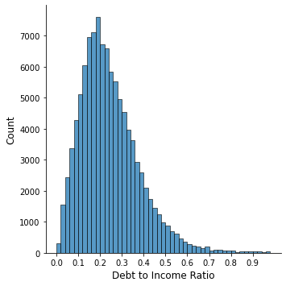

```python
# Look at the histogram of debt to income ratio
bins = np.arange(0, 1, .02);
sb.displot(loans['DebtToIncomeRatio'], kind = 'hist', bins=bins);
plt.xlabel('Debt to Income Ratio', fontsize=12);
plt.ylabel('Count', fontsize=12);
plt.xticks(np.arange(0, 1, .1));
```

#### The distribution of Debt to Income Ratio is right skewed with most of its values 0.14- 0.24.

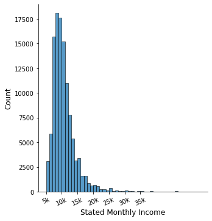

```python
# Look at the histogram of the Stated Monthly Income
bins = np.arange(0, 50000, 1000);
sb.displot(loans['StatedMonthlyIncome'], kind = 'hist', bins=bins);
plt.xticks(np.arange(0, 35000, 5000), labels=['5k', '10k', '15k', '20k', '25k', '30k', '35k'], rotation =25);
plt.xlabel('Stated Monthly Income', fontsize=12);
plt.ylabel('Count', fontsize=12);
```

#### Stated Monthly Income follows a normal distribution which is highly right skewed. Majority of monthly income falls below 15,000 dollars which is in line with expectations.

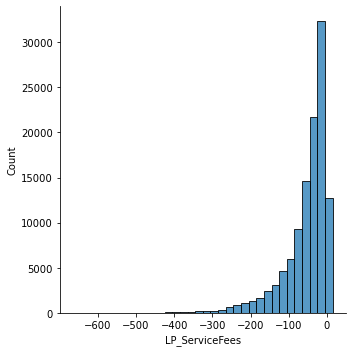

```python
##### Look at the histogram of the Cumulative service fees paid by the investors who have invested in the loan
bins = np.arange(loans['LP_ServiceFees'].min(), 20, 20)
sb.displot(loans['LP_ServiceFees'], kind = 'hist', bins = bins);
```

#### Cumulative service fee paid by the investors follows a severely left skewed distribution where most of the investors seem to be paying either no service fee or even receiving some money (between 0 to 500) to invest in the loans. However, there are about 8 cases where the investor has paid a small amount of service fee (< 50 dollars), to be able to invest in the loan of interest. These 8 cases might need to be investigated further as they seem to be outliers.

```python
(loans['LP_ServiceFees'] > 0).value_counts()
```

```
False    113929
True          8
Name: LP_ServiceFees, dtype: int64
```

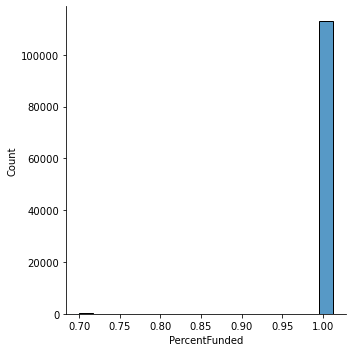

```python
# bins = np.arange(loans['PercentFunded'].max()+0.01, 0.01, .0001)
sb.displot(loans['PercentFunded'], kind = 'hist');
```

```python
loans['PercentFunded'].value_counts()
```

```
1.0000    113067
0.9998         5
0.7000         4
0.8087         4
0.7784         3
           ...
0.8167         1
0.7854         1
0.7903         1
0.7167         1
0.9575         1
Name: PercentFunded, Length: 719, dtype: int64
```

#### The distribution of the percentage of listings funded shows that more than 99% of the listings were fully funded. Some very few loans were funded at 70% or more.

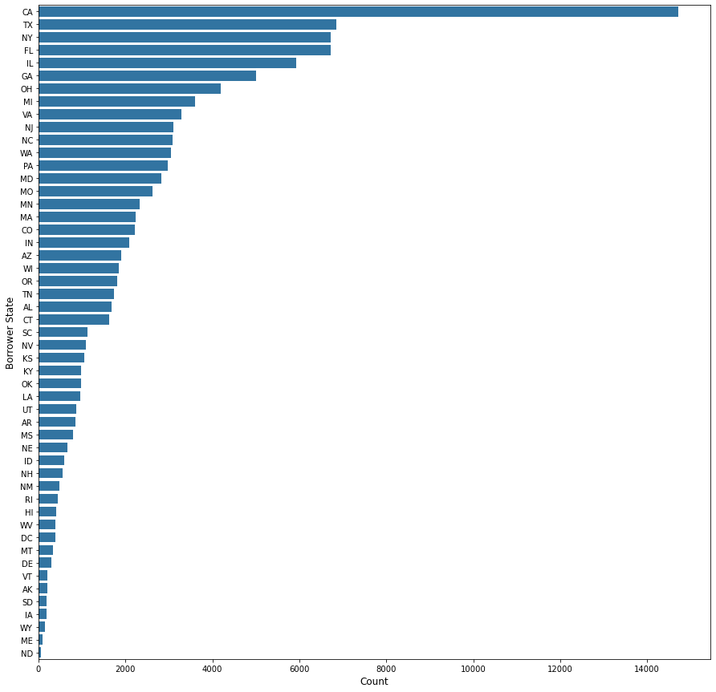

```python
# Look at the histogram of the borrower's state
plt.figure(figsize = [15, 15]);
base_color = sb.color_palette()[0]
sb.countplot(data = loans, y = 'BorrowerState', color = base_color,
             order = loans['BorrowerState'].value_counts().index);
plt.yticks(fontsize=10);
plt.ylabel('Borrower State', fontsize=12);
plt.xlabel('Count', fontsize=12);
```

#### As seen above, Californians hold the majority of Prosper loans more than double the number of loans by Texans, New Yorkers and Floridians. People from North Dakota, Maine and Wyoming, hold very few Prosper loans.

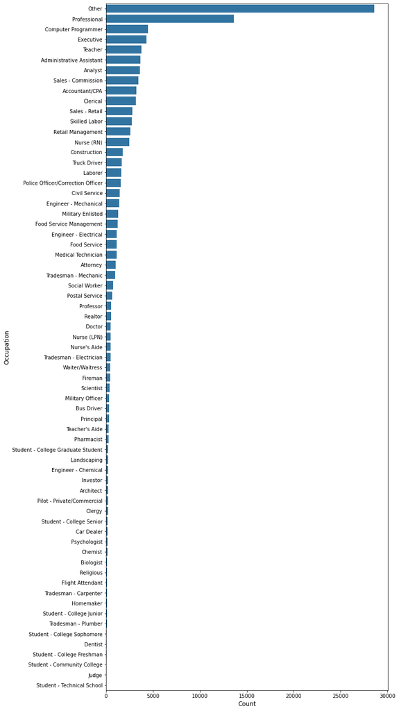

```python
# Look at the histogram of the borrower occupation
plt.figure(figsize = [10, 25]);
base_color = sb.color_palette()[0]
sb.countplot(data = loans, y = 'Occupation', color = base_color,
             order = loans['Occupation'].value_counts().index);
plt.yticks(fontsize=10);
plt.ylabel('Occupation', fontsize=12);
plt.xlabel('Count', fontsize=12);
```

```python
loans['Occupation'].value_counts()
```

```
Other                          28617
Professional                   13628
Computer Programmer             4478
Executive                       4311
Teacher                         3759
                               ...
Dentist                           68
Student - College Freshman        41
Student - Community College       28
Judge                             22
Student - Technical School        16
Name: Occupation, Length: 67, dtype: int64
```

#### Professionals, computer programmers and executives have the highest number of Prosper loans. Students, Judges, Dentists and plumbers hold very few loans.

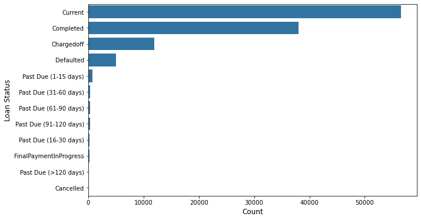

```python
# Look at the histogram of the loan outcome status
plt.figure(figsize = [10, 6]);
base_color = sb.color_palette()[0]
sb.countplot(data = loans, y = 'LoanStatus', color = base_color, order = loans['LoanStatus'].value_counts().index);
plt.yticks(fontsize=10);
plt.ylabel('Loan Status', fontsize=12);
plt.xlabel('Count', fontsize=12);
```

```python
loans.LoanStatus.value_counts()/(loans.LoanStatus.value_counts().sum())
```

```
Current                   0.496555
Completed                 0.334167
Chargedoff                0.105251
Defaulted                 0.044042
Past Due (1-15 days)      0.007074
Past Due (31-60 days)     0.003186
Past Due (61-90 days)     0.002747
Past Due (91-120 days)    0.002668
Past Due (16-30 days)     0.002326
FinalPaymentInProgress    0.001799
Past Due (>120 days)      0.000140
Cancelled                 0.000044
Name: LoanStatus, dtype: float64
```

```python
loans['LoanStatus'].value_counts()
```

```
Current                   56576
Completed                 38074
Chargedoff                11992
Defaulted                  5018
Past Due (1-15 days)        806
Past Due (31-60 days)       363
Past Due (61-90 days)       313
Past Due (91-120 days)      304
Past Due (16-30 days)       265
FinalPaymentInProgress      205
Past Due (>120 days)         16
Cancelled                     5
Name: LoanStatus, dtype: int64
```

## Bivariate Exploration

In this section, I will investigate relationships between pairs of variables in my data.

#### Before starting with individual bivariate plots, let's look at the pairwise relationships of our numerical variables of interest, to get an overal view on how to move forward with the exploration.

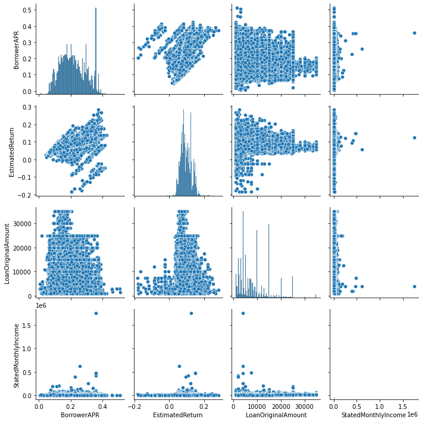

```python
sb.pairplot(loans, vars= ['BorrowerAPR',  'EstimatedReturn', 'LoanOriginalAmount',
                          'StatedMonthlyIncome']);
```

#### Pairplot shows that there is a positive correlation between borrower APR and estimated return. Also, There looks to be a negative correlation between borrower APR and original loan amount. Let's investigate these correlations further.

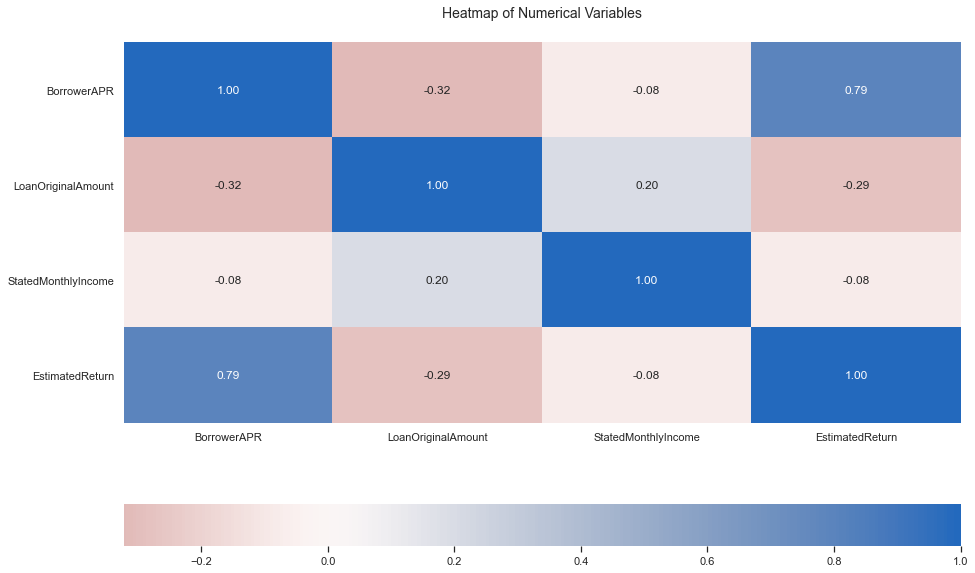

```python
numerical_vars = ['BorrowerAPR', 'LoanOriginalAmount',  'StatedMonthlyIncome',
                  'EstimatedReturn']
# Correlation Matrices
plt.figure(figsize = [15, 10])
grid_kws = {"height_ratios": (.5, .5), "hspace": .1}
sb.heatmap(loans[numerical_vars].corr(), annot = True, fmt = '.2f',
           cmap = 'vlag_r', center = 0, cbar_kws = {'orientation': 'horizontal'});
plt.title('Heatmap of Numerical Variables', fontsize=14, y=1.05);
```

#### As seen from the heatmap above, we can see a strong positive correlation between Borrower APR and Estimated Return with correlation coefficient of 0.79. Also, Borrower APR looks to have a negative relationship with the original loan amount. However, Borrower APR does not seem to be highly correlated with the Stated Monthly Income of the borrower. Let's look into these relationships further in the plots below as the above correlations are computed based on strength of linear relationship in the correlation matrices.

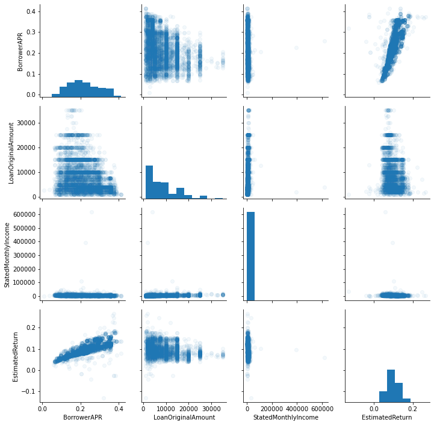

```python
# Sample 5,000 loans to make the plots readable and less busy
loans_sample = loans.sample(5000)
g = sb.PairGrid(data = loans_sample, vars = ['BorrowerAPR', 'LoanOriginalAmount',
                                             'StatedMonthlyIncome', 'EstimatedReturn'])
g = g.map_diag(plt.hist)
g.map_offdiag(plt.scatter, alpha = 0.05);
```

#### Looking at the correlation matrix, we can see that the correlation coefficient between the borrower APR and original loan amount is -0.32. We can also see the negative correlation between these two variables from the scatter plot above.

#### As seen from both the correlation matrices and the scatter plots, borrower APR has a strong positive correlation with the estimated return. The interesting relationships are the relationships between the stated monthly income with the borrower APR and the original loan amount. it looks like a correlation does not exist (correlation coefficient of -0.08 or 0.2 and the corresponding flat lines in the scatter plots). Let's dig deeper into this.

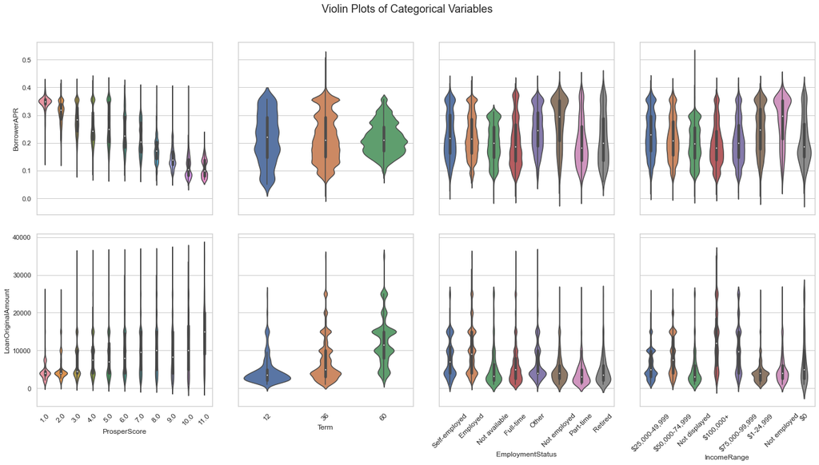

```python
categorical_vars = ['ProsperScore', 'Term', 'EmploymentStatus', 'IncomeRange']

# Plot numeric variables against categorical variables
plt.figure(figsize = [30, 30]);
base_color = sb.color_palette()[0];
g = sb.PairGrid(data = loans, x_vars = categorical_vars,
                y_vars = ['BorrowerAPR', 'LoanOriginalAmount'], despine=False);
g.map(sb.violinplot, inner = 'box', height=3, aspect=.8, saturation=0.75);
g.fig.set_size_inches(20,10);
for ax in g.axes.flat:
    ax.set_xticklabels(ax.get_xticklabels(), size = 12, rotation=45);
g.fig.suptitle('Violin Plots of Categorical Variables', fontsize=18, y=1.05);
```

#### From the violin plots above, we can conclude the following:

#### - Borrower APR decreases as the prosper score increases as expected. Borrower APR does not follow a specific trend with increasing loan term but it gets less variable as the term of the loan increases, Borrower APR decreases as the employment status improves from not employed to full-time employed and finally, borrower APR decreases as the monthly income range increases. Income range of 100,00 plus has the lowest APR whereas the not employed group has the highest APR. One interesting observation is the median borrower APR and IQR of the full-time employment looks to be bigger than that of part-time employment group.

#### - The original loan amount increases and varies more as the prosper rating improves, also, increasing the term of the loan might be a result of higher loan amounts which is expected. The interesting observation is that the employed category have the highest original loan amounts followed by the self-employed, the full-time employed and the not-employed group. The part-time employed look to have the lowest amount of loans. The 100k (USD) plus income range group has the biggest loans followed by 75k-100k (USD) and 50k-75k (USD).

## Multivariate Exploration

In this section, I will create plots of three or more variables to investigate the data even further.

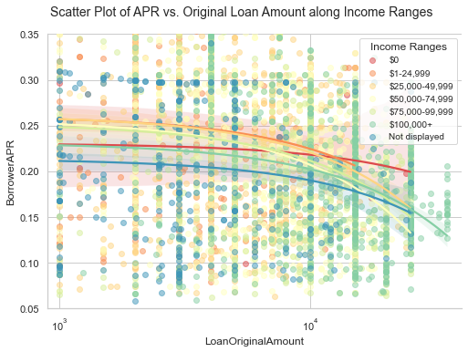

```python
g = sb.FacetGrid(data = loans_sample, hue = 'IncomeRange', hue_order = ['$0', '$1-24,999', '$25,000-49,999','$50,000-74,999','$75,000-99,999','$100,000+','Not displayed'], size = 5, aspect = 1.5, palette = 'Spectral');
g.map(sb.regplot,"LoanOriginalAmount", "BorrowerAPR", fit_reg = True, scatter_kws = {'alpha':.5});
plt.legend(title = 'Income Ranges', loc = 'best', fontsize = 10);
plt.xscale('log');
plt.xlim(900, 40000);
plt.ylim(.05, .35);
g.fig.suptitle('Scatter Plot of APR vs. Original Loan Amount along Income Ranges', fontsize=14, y=1.05);
```

#### At first look, the APR does not look to be following a specific trend against the income ranges based on the regression lines. If we look closer, there is a negative relationship between APR and income range for the majority of income ranges, however, since there are very few data points that belong to the 0 dollar income it looks like the trend doesn't exist. If we ignore the red line (0 income), we can claim that the higher the income gets, the lower is the APR overal. There might be other factors like the Prosper score and the overal risk profile of the borrower that might play into this relationship.

```python
loans['IncomeRange'].value_counts()
```

```
$25,000-49,999    32192
$50,000-74,999    31050
$100,000+         17337
$75,000-99,999    16916
Not displayed      7741
$1-24,999          7274
Not employed        806
$0                  621
Name: IncomeRange, dtype: int64
```

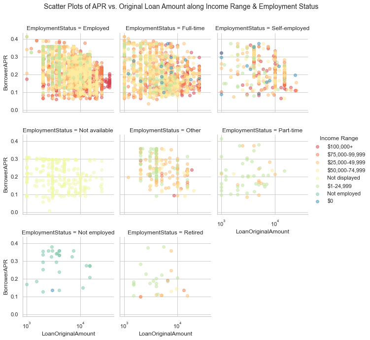

```python
sb.set_style("whitegrid");
g = sb.FacetGrid(data = loans_sample, col = 'EmploymentStatus', hue = 'IncomeRange', col_wrap = 3,
                  palette = 'Spectral');
g.map(plt.scatter, "LoanOriginalAmount", "BorrowerAPR", alpha=.5).add_legend(title="Income Range");
plt.xscale('log');
g.fig.suptitle('Scatter Plots of APR vs. Original Loan Amount along Income Range & Employment Status', fontsize=14, y=1.05);
```

#### The negative relationship between Borrower APR versus the original loan amount can be observed from the scatter plots above. We can see that the number of loans decrease as the employment status worsens. One interesting anamoly is the scatter plot of APR vs. LoanOriginalAmount which unlike all other plots, shows a positive correlation between APR and o riginal loan amount. This anomaly will be investigated further in the plot below.

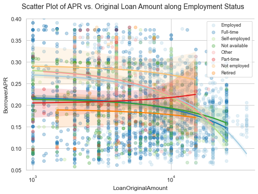

```python
g = sb.FacetGrid(data = loans_sample, hue = 'EmploymentStatus', size = 5, aspect = 1.5, palette = 'Paired');
g.map(sb.regplot,"LoanOriginalAmount", "BorrowerAPR", fit_reg = True, scatter_kws = {'alpha':.3});
plt.legend(loc=0, fontsize = 9);
plt.xscale('log');
plt.xlim(900, 40000);
plt.ylim(.05, .4);
g.fig.suptitle('Scatter Plot of APR vs. Original Loan Amount along Employment Status', fontsize=14, y=1.05);
```

#### We can see in the above scatter plot that the highest APR belongs to the not employed and the lowest APR belongs to the retired group, however, because of the limited number of data belonging to these 2 groups as well as the part-time group, we can not make claim that the relationship is statistically significant. When comparing the employed, full-time and the self-employed, it looks like the full-time and self-employed enjoy a lower APR than the employed group. These relationships might be influenced further by the income range and the borrower's overal financial risk. Similar to what we observed in the charts above, the part-time group's APR increases with increasing original loan amount.

```python
loans['EmploymentStatus'].value_counts()
```

```
Employed         67322
Full-time        26355
Self-employed     6134
Not available     5347
Other             3806
Part-time         1088
Not employed       835
Retired            795
Name: EmploymentStatus, dtype: int64
```

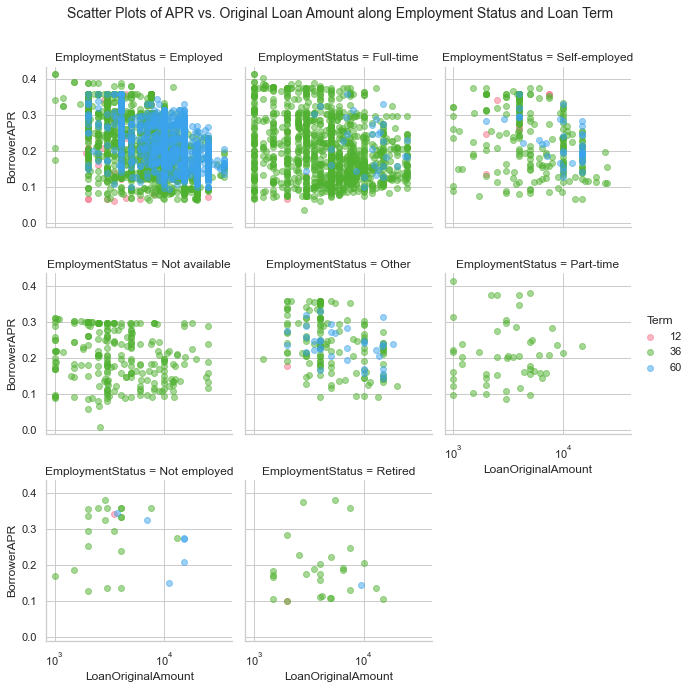

```python
g =  sb.FacetGrid(data = loans_sample, col = 'EmploymentStatus', hue = 'Term', col_wrap = 3, palette = 'husl');
g.map(plt.scatter, "LoanOriginalAmount", "BorrowerAPR", alpha=.5).add_legend();
plt.xscale('log');
g.fig.suptitle('Scatter Plots of APR vs. Original Loan Amount along Employment Status and Loan Term', fontsize=14, y=1.05);
```

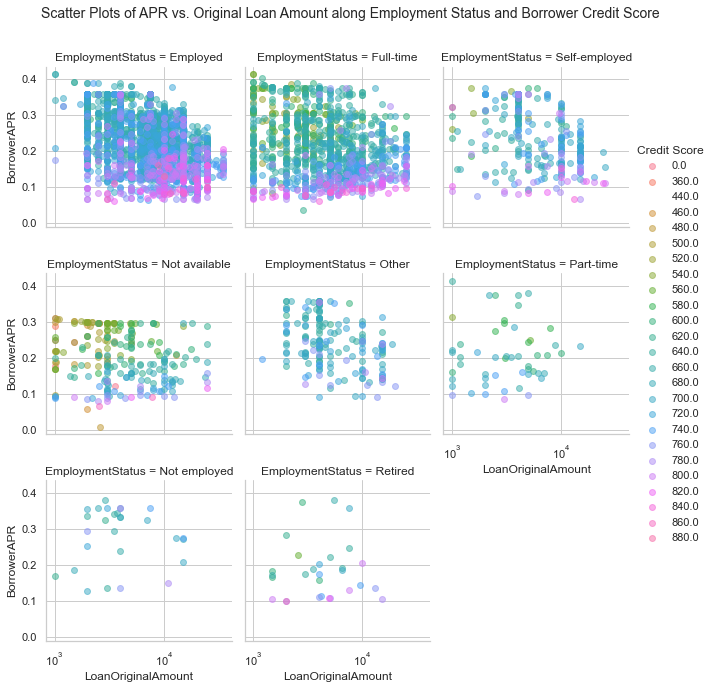

```python
g =  sb.FacetGrid(data = loans_sample, col = 'EmploymentStatus', hue = 'CreditScoreRangeLower', col_wrap = 3, palette = 'husl');
g.map(plt.scatter, "LoanOriginalAmount", "BorrowerAPR", alpha=.5).add_legend(title="Credit Score");
plt.xscale('log');
g.fig.suptitle('Scatter Plots of APR vs. Original Loan Amount along Employment Status and Borrower Credit Score', fontsize=14, y=1.05);
```

#### From the above scatter plots, we can see that the borrowers with the highest credit scores, enjoy the lowest APR loans in all employment groups. Moreover, the highest credit scores belong to the *Employed*, *Full-time* and *Self-employed* groups.